# Sales Analysis for Pens and Printers

### About Pens and Printers

Pens and Printers was founded in 1984 and provides high quality office products to large organizations.

### Business Problem

Six weeks ago we launched a new line of office stationery and since then, our focus has been on selling products to enable our customers to be more creative, focused on tools for brainstorming. We have tested three different sales strategies for this, targeted email and phone calls, as well as combining the two. We nee to know which of this method is the most efficient for us

## Data Analysis and Visualization

- What is the highest number of new products sold?

```
16
```

- What is the highest revenue from sales?

```
238.32
```

- What is the oldest customer number of years buying from the company?

[output not shown]

- What is the frequency of sales method?

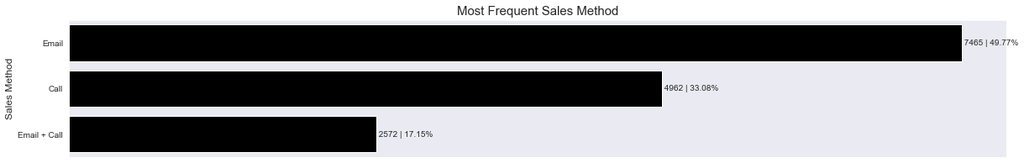

The most frequent sales method is the use of Email, followed by call and email+call

- Where do customers come from the most?

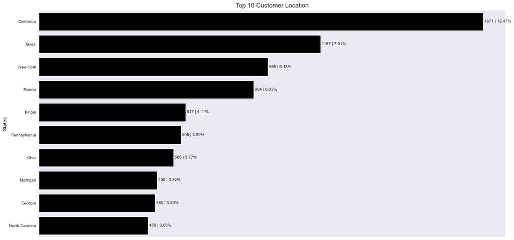

Most customers came from California, Texas, New York and Florida

- Which week has the highest records?

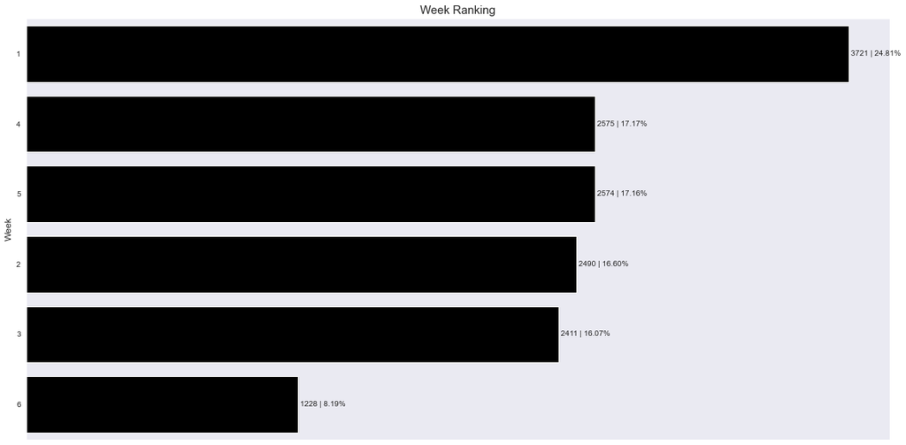

Week 1 had the highest occurrence followed by week 4, 5, 2, 3 and 6. This doesn't prove the most sales or revenue

- what is the distribution of the number of years as customer?

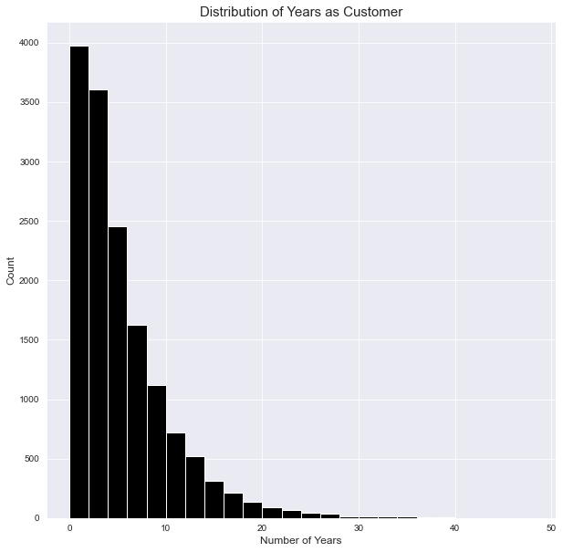

The distribution is a right skewed distribution with frequency reducing as the number of years increases

- What is the distribution of the number of visits to the company's site?

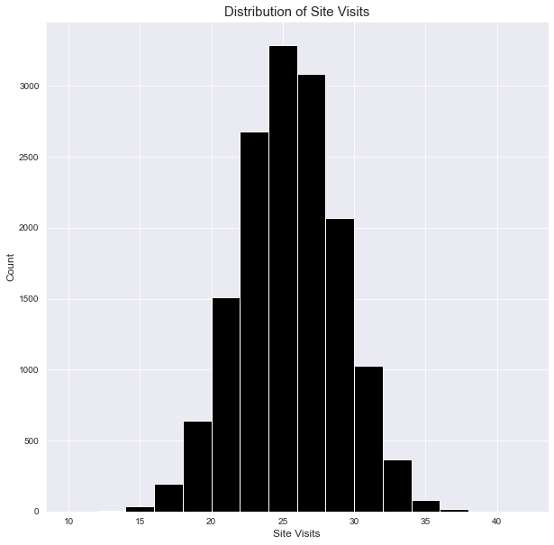

The number of visits to the company's site in the past 6 months is a normal distribution with a mean and median of 25

- Does the Revenue get affected by the week?

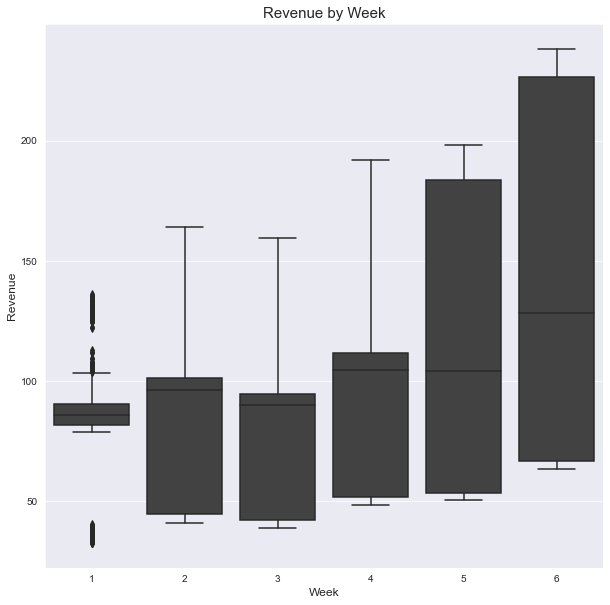

- Does the number of sales get affected by sales method?

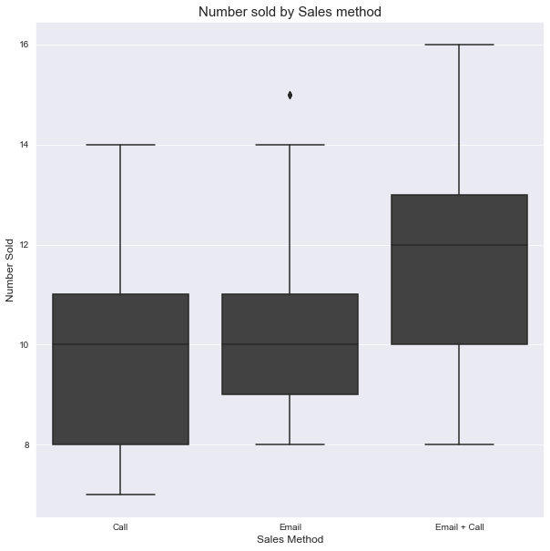

From the above chart, Call and Email sales method have the same median at 10 although call has a higher range of numbers. Email + Call had a higher median. This shows that the combination of email and call method of sale sold more new products despite the Email + Call having the lowest frequency.

- Does the revenue get affected by sales method?

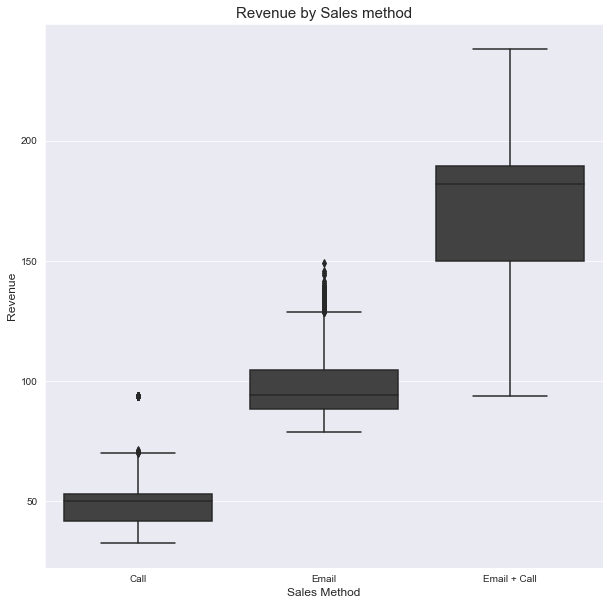

There's a very distinct gap between the sales methods in terms of revenue. Using email and the combination of email and call method would produce a much higher revenue than only call. All revenue gotten above 150 was gotten using the combination of email and call

- Does number of years as a customer and the week the sales was made have an effect on number of products sold?

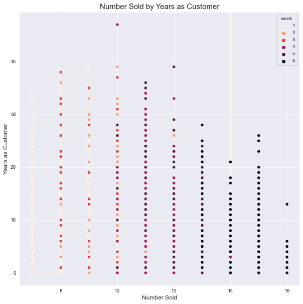

- Does the number of site visits affect the number of items sold?

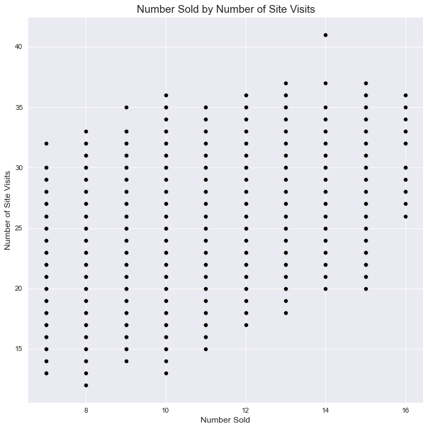

There seems to be a correlation between the number of site visits and the numbers sold. More site visits would likely lead to more sales.

- Does the number sold and week determine the revenue?

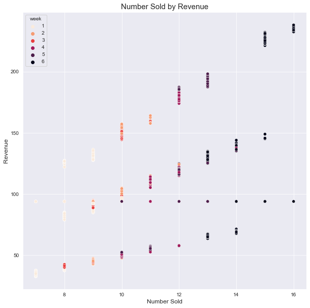

There is a positive correlation between the number sold and the revenue and the week the sales was made.

- Does the years as customer and week determine the revenue?

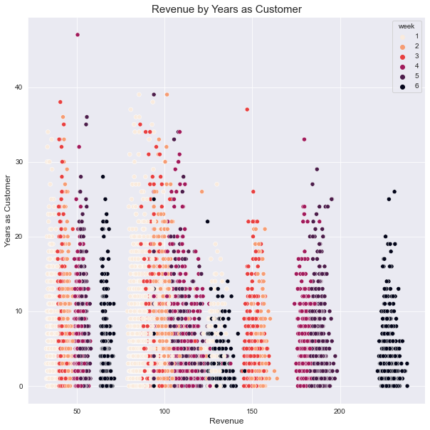

There is a pattern between the revenue and week the sales was made. This is in correlation with the box plot from earlier. Earlier weeks do not have higher revenue. This confirms that higher revenue is made from sales of later weeks

- How is revenue affected as the weeks progresses considering the sales method?

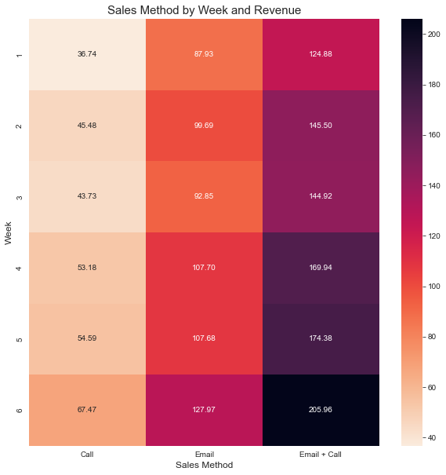

Email + Call had the highest revenue across the weeks. This performance is followed by Email and then the Call sales method

- How does the years as customers affect numbers sold and revenue

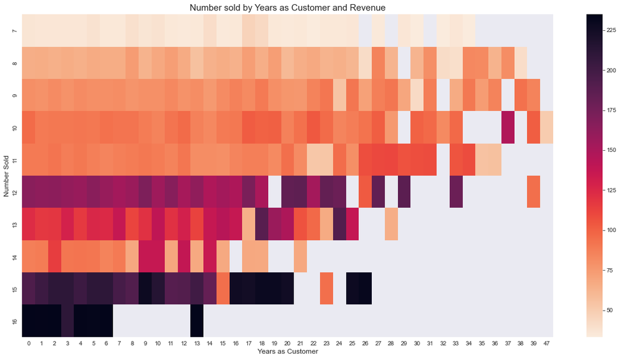

From this chart we can see that customers that buy more and generate more revenue are new customers. Older customers tend to buy less. This can also be due to the fact that there are fewer customers that are over 20 years as customers.

- What is the relationship between all the numberic values?

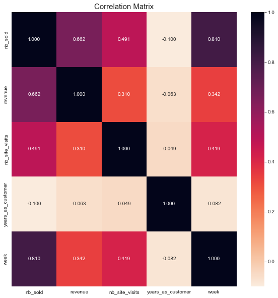

There is a strong correlation between numbers sold and week , numbers sold and revenue, numbers sold and number of site visites. The correlation between the numbers sold and number of site visits is not as strong as the others

## Business Solution

#### Definition of a metric for the business to monitor

The best metric for the business to monitor in this situation and with the data given is a productivity index which is equals to`The Revenue generated from sales method divided by (/) time spent on the sales method`. Tracking sales revenue can provide insights into the effectiveness of marketing and sales strategies, as well as how well products are performing in the market. Tracking the time can provide insights into which method is the most productive with the least amount of time.

#### How should the business use the metric to monitor the business problem?

The comparison between the Sales method and revenue gotten would tell a clear story on which sales method would be the best to use considering the time put into the execution of each method.

#### Can you estimate initial value(s) for the metric based on the current data?

Based on the current data, The average revenue from Call is 49.28, Email is 96.89 and Email + Call is 171.47. Given that Call takes 30 minutes and the call in the Email + Call method takes 10 minutes and assuming that sending each email takes 5 minutes

| Sales Method | Average Revenue | Time Taken | Productivity Index |
| --- | --- | --- | --- |
| Call | 49.28 | 30 | 1.64 |
| Email | 96.89 | 10 (2 emails) | 9.68 |
| Email + Call | 171.47 | 15 | 11.43 |

The most productive method is the Email + Call method. Considering the Average Revenue generated and the amount of effort put into by the sales team

## Summary of findings

- The highest number of new products sold at a time is 16 and the highest revenue gotten from products sold to a customer is 238.32 with 16 items bought
- The top five location of the customers are California, Texas, New York, Florida, and Illinois
- The combination of email and call method of sale sold more new products and created more revenue despite the combination being the least used.
- Week 1 has a higher count of customers followed by week 4, 5, 2, 3 and 6. However, this doesn't determine much as the revenue increases as the weeks since product launch goes by making week 6 have the highest revenue. This pattern is also seen with the number of items sold. More items are sold in the later weeks.
- Years as a customer does not determine the number of site visits
- Customers that buy more and generate more revenue are new customers. Older customers tend to buy less and this can also be due to the fact that there are fewer customers that have over 20 years as customers.

## Conclusion and Recommendations

- Considering that the combination of Email and Call produces the most revenue and is the most productive according to the defined metric, Pens and Printers should intensify their efforts in the sales method of Email and Call
- Since the most sales and revenue from products are gotten 4-6 weeks after the lunch of the product, this would indicate that the products are bought after the second reminder which could be the email or call. Pens and Printers should make an effort to remind customers earlier
- As older customers tend to buy less, there should be some sort of incentive or promo run to reinitiate the interest of older customers